# Sales Analysis

2020-2023

Rashaad Mohammed Mirza

Summer 2024

# Report

## AQI: Top 5 Products by Total Revenue (2020-2023)

The table and chart below show the top five products that generated the most revenue over the period from 2020 to 2023. This analysis helps in identifying the best-performing products and can guide strategic decisions such as inventory management, marketing focus, and sales strategies.

Top 5 Products by Total Revenue (2020-2023)

| product | total_revenue |
| --- | --- |
| Zalofen | 90179700 |
| Bhiktarvizem | 9442800 |
| Xinoprozen | 6786612 |
| Xipralofen | 5777688 |
| Proxinostat | 5337951 |

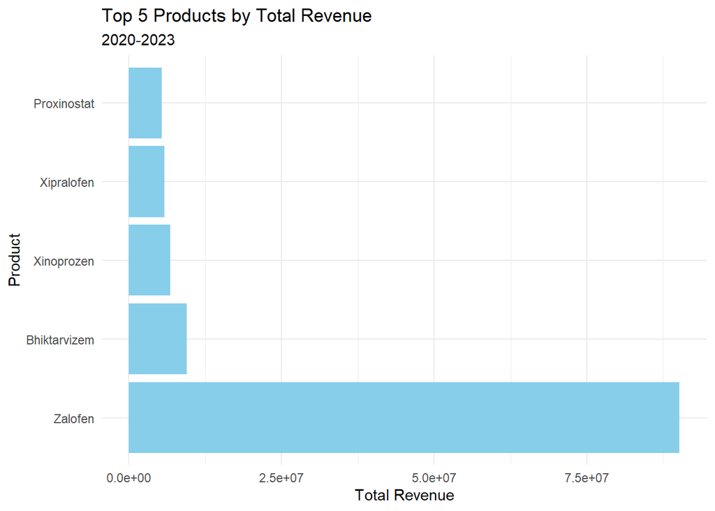

## AQII: Total Revenue and Units Sold per Product per Quarter (2020-2023)

The following analysis provides a breakdown of total revenue and units sold for each product on a quarterly basis. This information is useful for understanding seasonal trends, identifying products with consistent performance, and recognizing quarters with exceptional sales performance.

### Total Revenue and Units Sold per Product per Quarter

The table below shows the total revenue and units sold per product for each quarter from 2020 to 2023.

Total Revenue and Units Sold per Product per Quarter

| product | year | quarter | total_revenue | total_units_sold |
| --- | --- | --- | --- | --- |
| Alaraphosol | 2020 | 1 | 102120 | 111000 |
| Alaraphosol | 2020 | 2 | 105248 | 114400 |
| Alaraphosol | 2020 | 3 | 112792 | 122600 |
| Alaraphosol | 2020 | 4 | 80868 | 87900 |
| Alaraphosol | 2021 | 1 | 193844 | 210700 |
| Alaraphosol | 2021 | 2 | 210404 | 228700 |
| Alaraphosol | 2021 | 3 | 209760 | 228000 |
| Alaraphosol | 2021 | 4 | 193660 | 210500 |
| Alaraphosol | 2022 | 1 | 183724 | 199700 |
| Alaraphosol | 2022 | 2 | 214084 | 232700 |
| Alaraphosol | 2022 | 3 | 202584 | 220200 |
| Alaraphosol | 2022 | 4 | 145820 | 158500 |
| Alaraphosol | 2023 | 1 | 76728 | 83400 |
| Alaraphosol | 2023 | 2 | 99452 | 108100 |
| Alaraphosol | 2023 | 3 | 105892 | 115100 |
| Alaraphosol | 2023 | 4 | 93472 | 101600 |
| Bhiktarvizem | 2020 | 1 | 313083 | 80900 |
| Bhiktarvizem | 2020 | 2 | 422217 | 109100 |
| Bhiktarvizem | 2020 | 3 | 523224 | 135200 |
| Bhiktarvizem | 2020 | 4 | 332046 | 85800 |
| Bhiktarvizem | 2021 | 1 | 766647 | 198100 |
| Bhiktarvizem | 2021 | 2 | 870363 | 224900 |
| Bhiktarvizem | 2021 | 3 | 806895 | 208500 |
| Bhiktarvizem | 2021 | 4 | 644742 | 166600 |
| Bhiktarvizem | 2022 | 1 | 731817 | 189100 |
| Bhiktarvizem | 2022 | 2 | 873846 | 225800 |
| Bhiktarvizem | 2022 | 3 | 948924 | 245200 |
| Bhiktarvizem | 2022 | 4 | 670284 | 173200 |
| Bhiktarvizem | 2023 | 1 | 334755 | 86500 |
| Bhiktarvizem | 2023 | 2 | 419508 | 108400 |

[output cut: 162 more lines]

### Total Revenue per Product per Quarter

The bar chart below visualizes the total revenue for each product, broken down by quarter. This helps in identifying which products performed best in specific quarters.

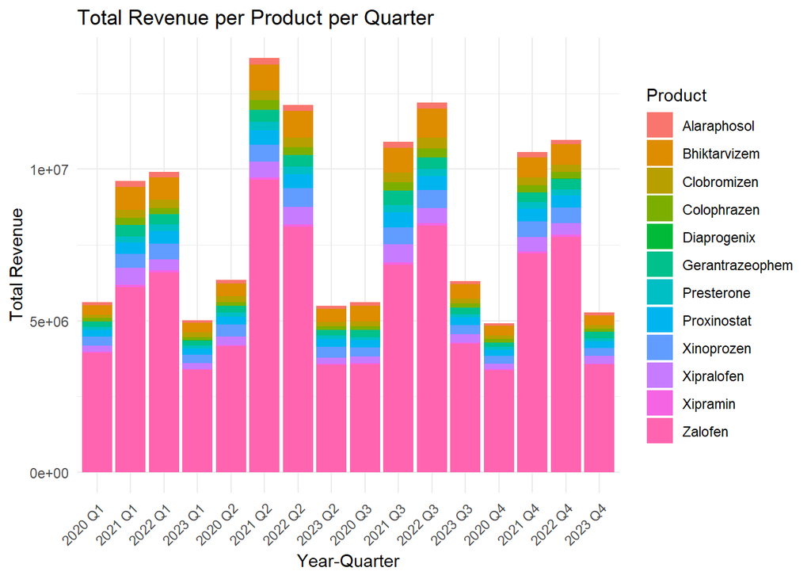

### Total Units Sold per Product per Quarter

The line chart below illustrates the total units sold for each product per quarter, highlighting trends in product demand over time.

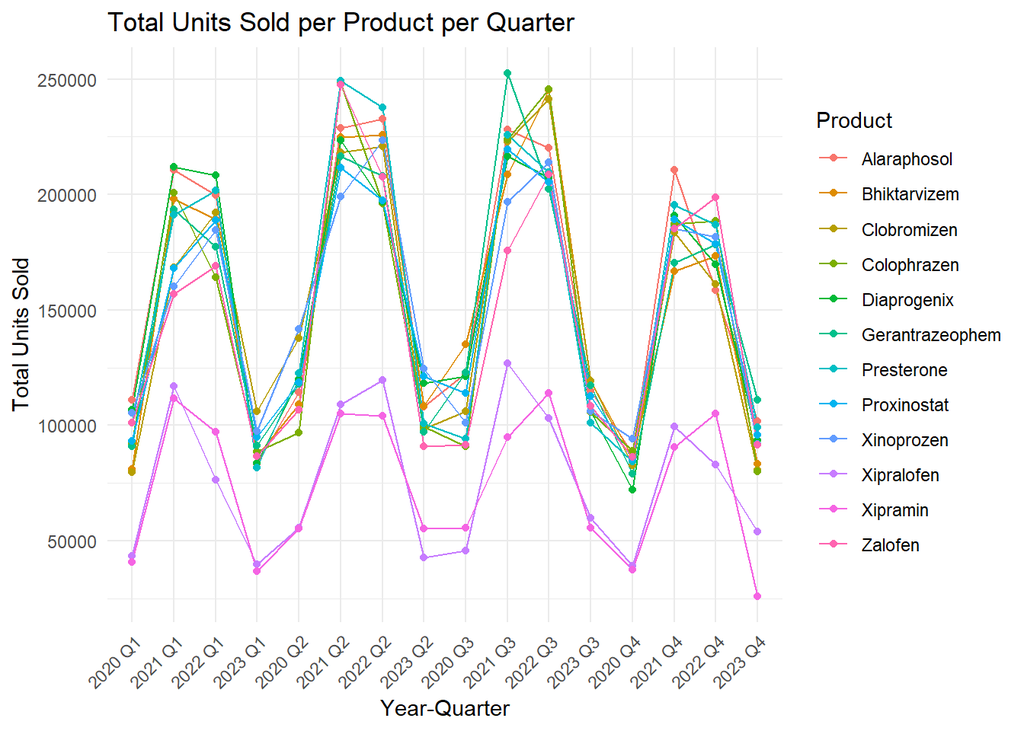

## AQIII: Total Revenue per Product per Country (2020-2023)

[figure not shown]

## AQIV: Average Sales per Sales Rep per Quarter (2020-2023)

The table below shows the average sales amount per sales rep for each quarter from 2020 to 2023. This information helps to easily identify key sales reps and their average sales performance across different quarters.

Average Sales per Sales Rep per Quarter

| rID | sur | first | year | quarter | avg_sales |
| --- | --- | --- | --- | --- | --- |
| 887 | da Silva | Walison | 2020 | 1 | 565853.33 |
| 203 | Kappoorthy | Aneeta | 2020 | 1 | 356211.33 |
| 332 | McRowe | Lynette | 2020 | 1 | 340226.67 |
| 119 | Patel | Prasad | 2020 | 1 | 213589.00 |
| 655 | Klinger | Ralph | 2020 | 1 | 166944.00 |
| 100 | Schwab | Helmut | 2020 | 1 | 159320.00 |
| 221 | Sixt | Veronika | 2020 | 1 | 69505.33 |
| 887 | da Silva | Walison | 2020 | 2 | 690640.67 |
| 332 | McRowe | Lynette | 2020 | 2 | 431968.33 |
| 203 | Kappoorthy | Aneeta | 2020 | 2 | 341065.33 |
| 119 | Patel | Prasad | 2020 | 2 | 247023.67 |
| 100 | Schwab | Helmut | 2020 | 2 | 230963.67 |
| 655 | Klinger | Ralph | 2020 | 2 | 105516.33 |
| 221 | Sixt | Veronika | 2020 | 2 | 65376.00 |
| 887 | da Silva | Walison | 2020 | 3 | 533532.67 |
| 203 | Kappoorthy | Aneeta | 2020 | 3 | 375374.33 |
| 332 | McRowe | Lynette | 2020 | 3 | 346709.00 |
| 119 | Patel | Prasad | 2020 | 3 | 211586.33 |
| 655 | Klinger | Ralph | 2020 | 3 | 162256.00 |
| 100 | Schwab | Helmut | 2020 | 3 | 148037.33 |
| 221 | Sixt | Veronika | 2020 | 3 | 88914.33 |
| 887 | da Silva | Walison | 2020 | 4 | 490614.67 |
| 332 | McRowe | Lynette | 2020 | 4 | 299578.33 |
| 100 | Schwab | Helmut | 2020 | 4 | 273548.00 |
| 203 | Kappoorthy | Aneeta | 2020 | 4 | 196391.67 |
| 119 | Patel | Prasad | 2020 | 4 | 157994.33 |
| 655 | Klinger | Ralph | 2020 | 4 | 130330.67 |
| 221 | Sixt | Veronika | 2020 | 4 | 91840.67 |
| 887 | da Silva | Walison | 2021 | 1 | 798972.00 |
| 332 | McRowe | Lynette | 2021 | 1 | 684590.67 |

[output cut: 82 more lines]

# References:

# https://www.youtube.com/watch?v=H6no78vdNUM

# https://northeastern.instructure.com/courses/180750/modules

# https://www.geeksforgeeks.org/fact-constellation-in-data-warehouse-modelling/

# https://chatgpt.com/

# https://www.databricks.com/glossary/snowflake-schema#:~:text=A%20snowflake%20schema%20is%20a,data%20marts%2C%20and%20relational%20databases.

# https://community.fabric.microsoft.com/t5/Desktop/Same-Dimensions-multiple-Fact-tables-different-measures-millions/td-p/3212805#:~:text=Given%20your%20requirements%2C%20there%20are%20a%20few%20potential%20approaches%20to%20consider.&text=Creating%20a%20star%20schema%20with,a%20bridge%20table%20where%20necessary.

# https://stackoverflow.com/questions/32139596/cannot-allocate-a-new-connection-16-connections-already-opened-rmysql

# https://www.lucidchart.com/pages/tour [ERD]

# https://www.phpmyadmin.co/index.php [Console]